Kvinnor och män i Dalarna

# Kvinnor och män i Dalarna

Rapporten är skapad av Samhällsanalys, Region Dalarna  
Senast uppdaterad: 2025-03-06

# Sammanfattning

Det övergripande målet för jämställdhetspolitiken är att kvinnor och män ska ha samma makt att forma samhället och sina egna liv. Utvecklingen bör följas med både kvalitativa och kvantitativa mått då det handlar om både makt och representation. Denna rapport ger en bild av nuläget i Dalarna för fem av jämställdhetspolitikens sex delmål i kvantitativa termer med en kvalitativ analys. Rapporten ger en kommunal och regional fördjupning som komplement till SCB:s skrift *På tal om kvinnor och män*. De viktigaste trenderna och mönstren i Dalarna visar att:

- Andelen högutbildade ökar bland både kvinnor och män, men andelen kvinnor ökar i högre takt. Idag är nästan dubbelt så många kvinnor som män i Dalarna högutbildade.
- Obalansen mellan tjejers och killars val till gymnasieprogrammen består. Endast fem program av tjugo har en jämn representation av tjejer och killar.
- I likhet med riket som helhet har kvinnor i Dalarna en avsevärt lägre medianinkomst än män, även om kvinnors inkomster har ökat i något högre takt än mäns de senaste decennierna.
- Föräldrapenningdagarna fördelas betydligt jämnare mellan föräldrarna nu, i jämförelse med början av 1990-talet, men fördelningen i Dalarna är fortfarande långt ifrån jämställd.
- Kvinnors ohälsa mätt genom frånvaro från arbetsplatsen är betydligt mer omfattande än mäns. Skillnaden gäller oavsett bransch, och är tydligast när det gäller stressrelaterade symtom.
- Inom politiken har representationen av kvinnor och män på förtroendeposter under de senaste årtiondena jämnats ut. Det råder dock fortfarande stora skillnader på lokal nivå och fyra av Dalarnas kommuner har en övervikt (mer än 60 %) av män i fullmäktige.

# Introduktion

Världsläget synliggör fundamentala utmaningar för demokratiska samhällen, samtidigt som en konstruktiv diskussion om jämställdhet i stort förefaller ha kommit i skymundan i den allmänna debatten. Att sträva efter jämställdhet är trots det en av de mer centrala insatserna för att säkerställa mänskliga rättigheter och att uppnå de 17 målen i Agenda 2030 tillsammans med nationella miljö- och demokratimål med flera politiskt beslutade mål för ett demokratiskt samhälle.

För Dalarna är de regionala målen manifesterade i [Dalastrategin 2030 - Tillsammans för ett hållbart Dalarna](https://www.regiondalarna.se/contentassets/699fddaa79da4978bfe14dd4bead1134/dalastrategin-2030-tillsammans-for-ett-hallbart-dalarna-dec.pdf), med övergripande målsättning om ett sammanhållet Dalarna med goda livsmiljöer där människor skapar delaktighet och engagemang, och bidrar till en hållbar utveckling.

Alla offentliga verksamheter i Dalarna så som Region Dalarna, Länsstyrelsen Dalarna, länets kommuner och lärosäte arbetar på olika sätt aktivt för att efterleva den regionala och nationella jämställdhetpolitiken och respektive organisations särskilt uppsatta mål för jämställdhet. Följande rapport är tänkt att ge en bild av hur jämställdheten utvecklas i Dalarna baserat på den statistik som finns tillgänglig på regional och kommunal nivå. I rapporten diskuteras även läget i relation till nationella trender och utmaningar.

Region Dalarna har tidigare publicerat uppföljningar av läget i Dalarna på webben, år 2022, 2023 och 2024, och en fördjupande uppföljning av jämställdhet i länet år 2019 [Kvinnor och män i Dalarna ur ett jämställdhetsperspektiv](https://www.regiondalarna.se/contentassets/d845727dbc9f49c3b7b09a2c60456497/jamstalldhetsrapport.pdf)[^1] som togs fram inom projektet Jämställd regional tillväxt.

Det görs även nationella uppföljningar av jämställdhetspolitiken. För mer information om dessa, klicka på rutan nedan:

**Nationella uppföljningar av jämställdhetspolitiken**

Nationella uppföljningar av hur jämställdhetspolitiken bidrar till målen görs både genom statistik- och policy-analyser. Statistiska uppföljningar görs av bland andra Statistiska centralbyrån (SCB) som vart annat år (sedan 1984) publicerar skriften [På tal om kvinnor och män](https://www.scb.se/webbrapporter/le0201/lathund2024/)[^2] och vart tionde år (sedan 1990) gör [tidsanvändningsstudier](https://www.scb.se/contentassets/4e98132b0b784a01b6e4762e909a6fa2/le0103_2021a01_br_lebr2202.pdf)[^3], nu senast 2021. Vidare analyseras årligen i regeringens budgetproposition hur den ekonomiska jämställdheten utvecklas, vilket redovisas i [Prop. 2024/25:1 bilaga 3 Ekonomisk jämställdhet](https://www.regeringen.se/contentassets/b6626ad4c65b42f7a56e3cac029eca70/ekonomisk-jamstalldhet.pdf)[^4].

Policy-uppföljningar av jämställdhetspolitiken görs av bland andra Jämställdhetsmyndigheten. Myndigheten har även granskat den regionala politiken ur ett jämställdhetsperspektiv. I rapporten [Regionalpolitik, könsmönster och jämställdhetsambitioner](https://jamstalldhetsmyndigheten.se/media/xkfccjgj/rapport-2022-16-bilaga-1-regionalpolitik-ko-nsmo-nster-och-ja-msta-lldhetsambitioner.pdf)[^5] finns en fördjupning om läget i regionerna. Här påpekas bland annat att det behövs en bättre styrning mot jämställdhetsmålen genom relevanta indikatorer. Mer konkret handlar det bland annat om att följa upp och förebygga ojämställda arbetsvillkor, ojämställda inkomster, kvinnors och mäns psykiska ohälsa och långtidssjukskrivningar, och synliggöra regionala och lokala könsmönster samt intersektionella perspektiv.

# 1 Utbildning och yrken

Det jämställdhetspolitiska delmålet för utbildningsområdet innebär att kvinnor och män, tjejer och killar, ska ha samma möjligheter och villkor när det gäller utbildning, studieval och personlig utveckling.

Både kvinnor och män vidareutbildar sig efter gymnasiet i högre utsträckning idag än föregående generationer, men betydligt fler kvinnor än män studerar vid universitet och högskola. Att skillnaderna i vidareutbildning ökar mellan könen är negativt för samhällsutvecklingen, då det riskerar att medföra att olika former av könssegregerade miljöer skapas eller upprätthålls. Det medför även skilda förutsättningar på arbetsmarknaden mellan gruppen kvinnor och gruppen män, då eftergymnasial utbildning ger större chans till arbete och möjlighet till högre inkomst.

## 1.1 Utbildningsnivåer

De senaste decennierna har utbildningsnivån bland befolkningen i Dalarna ökat generellt och särskilt andelen med högre utbildning. I mitten av 1980-talet hade bara drygt sju procent av befolkningen en högre utbildning. År 2023 hade den andelen ökat till drygt 30 procent för kvinnor och knappt 16 procent för män. Anmärkningsvärt är dock att skillnaden i utbildningsnivå mellan könen har ökat avsevärt genom åren. I mitten av 1980-talet var andelen högutbildade ungefär lika stor bland kvinnor och män. År 2023 var nästan dubbelt så stor andel kvinnor som män högutbildade i Dalarna.

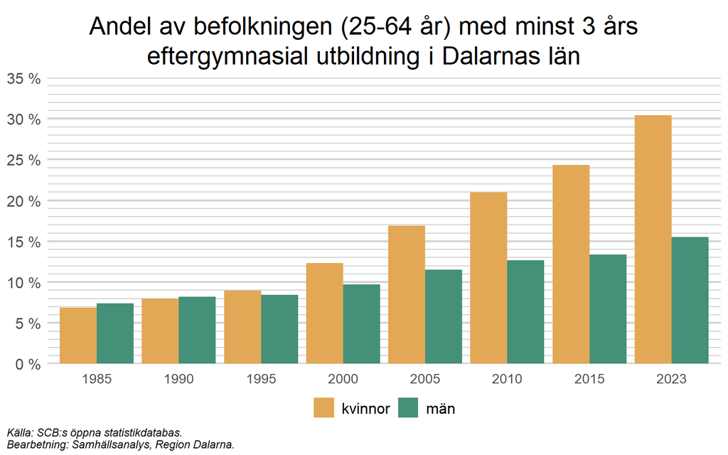

I nationell jämförelse har Dalarna en relativt låg andel personer med högre utbildning. I hela riket har 38 procent av kvinnorna och 24 procent av männen i åldersgruppen 25-64 år minst 3 års eftergymnasial utbildning, medan andelen kvinnor i Dalarna med en högre utbildning om minst 3 år 2023 är ungefär 30 procent och motsvarande siffra för män i länet är cirka 15 procent. Detta utfall placerar Dalarna sämst i landet tillsammans med Gävleborgs, Kalmars och Södermanlands län som har liknande låga siffror.

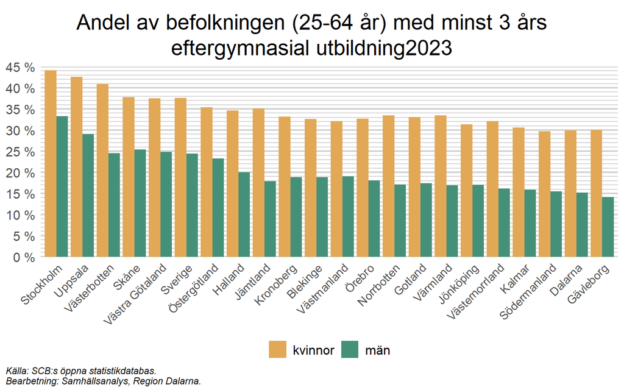

Generellt tenderar regioner med större urbana center att både ha en yngre och en mer välutbildad befolkning jämfört med mer glest befolkade län som Dalarna. Skillnaden är störst bland män, där andelen högutbildade män i Stockholms län är mer än dubbelt så hög som motsvarande andel i Dalarnas län.

En strukturell faktor som kan bidra till könsskillnaden i utbildningsnivå är att många yrken inom kvinnodominerade sektorer så som utbildning och vård kräver högskoleutbildning, exempelvis läraryrket och sjuksköterskeyrket. Dessa yrken utgör också en stor andel av arbetstillfällena på arbetsmarknaden.

Utbildningsnivån påverkar inte bara livsinkomsten utan även medellivslängden. För personer som uppnått 65 års ålder skiljer mer än tre år i medellivslängd mellan dem som har förgymnasial utbildning och dem med eftergymnasial utbildning. Skillnaden mellan könen är genomgående cirka två år, vilket innebär att kvinnor i respektive utbildningsgrupp lever i genomsnitt två år längre än män i samma utbildningsgrupp. Samtidigt visar det sig att boenderelationer också påverkar medellivslängden, och särskilt för män. Män med förgymnasial utbildning som är sammanboende lever i genomsnitt längre än ensamstående män med eftergymnasial utbildning. Sämst utsikter, genomsnittligt, för ett långt liv har således ensamstående män med låg utbildningsnivå [(SCB)](https://www.statistikdatabasen.scb.se/pxweb/sv/ssd/START__BE__BE0701/LivslUtbHushtyp/).

Utbildningsnivån inom åldersgruppen 25-64 år i Dalarna år 2023 enligt figuren nedan visar på stora skillnader mellan könen. En betydligt större andel kvinnor i länet har en högre utbildning i jämförelse med andelen män med högre utbildning. Bland kvinnor i Dalarna är den vanligaste, med 30 procent, utbildningsnivån “eftergymnasial utbildning, 3 år eller mer”. Motsvarande andel bland män i Dalarna är 15 procent. Bland män i Dalarna är i stället den vanligast förekommande utbildningskategorin”gymnasial utbildning, 3 år”. Ungefär 32 procent av männen i Dalarna återfinns inom denna kategori.

Räknas alla typer av eftergymnasial utbildning samman är det totalt 45 procent av kvinnorna i Dalarna som har någon form av eftergymnasial utbildning och bland män i länet är motsvarande siffra cirka 28 procent.

Även inom utbildningsnivån gymnasieutbildning om högst 2 år är en större andel män än kvinnor, 25 procent av männen har en gymnasieutbildning om högst 2 år, medan 18 procent av kvinnorna har en gymnasieutbildning om högst 2 år.

Sammantaget innebär detta att ungefär 57 procent av alla män i Dalarna har en gymnasieutbildning som högsta utbildning. Bland kvinnor är motsvarande andel i Dalarna 44 procent.

Utbildningsnivån inom åldersgruppen 25-64 år i Dalarna år 2023 enligt figuren nedan visar på stora skillnader mellan könen. En betydligt större andel kvinnor i länet har en högre utbildning i jämförelse med andelen män med högre utbildning. Bland kvinnor i Dalarna är den vanligaste, med 30 procent, utbildningsnivån “eftergymnasial utbildning, 3 år eller mer”. Motsvarande andel bland män i Dalarna är 15 procent. Bland män i Dalarna är i stället den vanligast förekommande utbildningsnivån “gymnasial utbildning, 3 år”. Ungefär 32 procent av männen i Dalarna återfinns inom denna kategori.

Räknas alla typer av eftergymnasial utbildning samman är det totalt 45 procent av kvinnorna i Dalarna som har någon form av eftergymnasial utbildning och bland män i länet är motsvarande siffra cirka 28 procent.

Då en relativt liten andel män har högskoleutbildning återfinns männen i stället i de lägre utbildningsgrupperna. I gruppen med gymnasieutbildning om högst 2 år återfinns 25 procent av männen, medan 18 procent av kvinnorna har en gymnasieutbildning om högst 2 år.

Sammantaget innebär detta att ungefär 57 procent av alla män i Dalarna har en gymnasieutbildning som högsta utbildning. Bland kvinnor är motsvarande andel i Dalarna 44 procent.

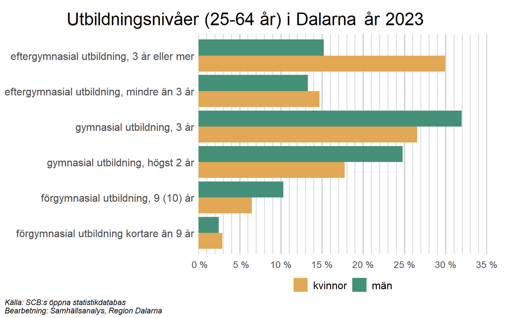

## 1.2 Gymnasieutbildning och examen

En utmaning för länet är den obalans som råder i antalet antagna killar och tjejer till gymnasieprogrammen i Dalarna. Av totalt 20 gymnasieprogram i länet kan endast fem sägas vara jämställda, dvs. de har en könsfördelning där andelen antagna är mellan 40 och 60 procent för både killar och tjejer. De program som har en jämställd representation vid antagningen är international baccalaurate, naturvetenskapsprogrammet, ekonomiprogrammet, introduktionsprogram samt restaurang och livsmedelsprogrammet. Sex program har en övervikt av killar, där VVS- och fastighetsprogrammet har den största obalansen, följt av el- och energiprogrammet samt industritekniska programmet. Resterande nio program har en övervikt av tjejer, där vård- och omsorgsprogrammet är det mest obalanserade programmet följt av hantverksprogrammet och det humanistiska programmet.

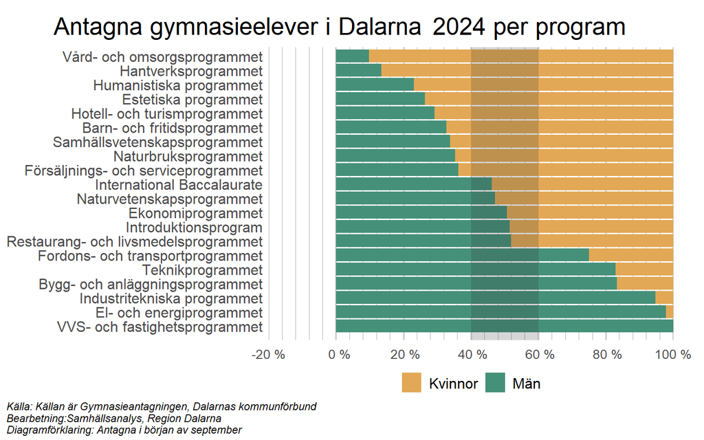

I diagrammet nedan visas genomströmningen i gymnasieskolan genom andelen med studiebevis alternativt examen 4 år efter påbörjat gymnasium. Tidigare var det generella mönstret att cirka 80 procent av tjejerna klarat av gymnasiet inom 4 år, medan andelen bland pojkarna har varit lägre (runt 75 procent). Under pandemiåren 2020 och 2021 försämrades genomströmningen, men därefter har andelen med studiebevis ökat för båda könen, men extra mycket för killarna. År 2024 var andelen med studiebevis ungefär 83 procent bland tjejer och 79 procent bland killar.

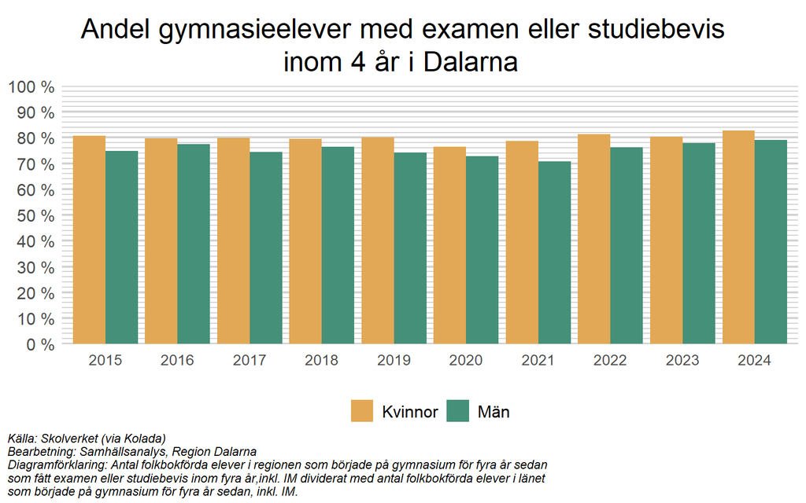

## 1.3 Yrken och branscher

Många arbetsuppgifter och yrken har historiskt varit könsuppdelade. Med könsuppdelningen har även värderingar om vad som räknats som formellt respektive informellt arbete synliggjorts, och hur dessa arbeten värderats i pengar. Politiska beslut har på flera sätt påverkat detta. Innan exempelvis reformerna som etablerade barn- och äldreomsorg på den reguljära arbetsmarknaden utförde kvinnor detta omsorgsarbete obetalt eller på annat sätt utanför ordinarie arbetsmarknad. När dessa arbetsuppgifter övergick till formellt arbete medförde det många positiva effekter för både kvinnor och män, men det blev på många sätt naturligt att framförallt kvinnor befolkade dessa tjänster. Dessvärre har det bidragit till en bestående könssegregering på arbetsmarknaden, som förefaller svår att förändra.

Sedan många år har kvinnor och män haft likvärdig tillgång till utbildning och möjlighet att fritt välja yrke. Trots detta består många av könsskillnaderna i arbetslivet (se figuren nedan) och de yngre generationerna tycks inte göra mindre könsstereotypa val, som redovisats ovan. Många branscher i länet idag har en tydlig övervikt av det ena eller det andra könet, exempelvis byggbranschen som omfattar yrken inom bland annat el och VVS, och där kvinnor bara utgör ungefär 9 procent av de förvärvsarbetande. Även om det har skett en ökning av andelen kvinnor inom byggbranschen är denna ökning ännu liten i sammanhanget. Inom vård och omsorg är bilden densamma men med motsatt könsfördelning. Här utgör kvinnor cirka 77 procent av de förvärvsarbetande.

Att åstadkomma en förändring i närtid av balansen mellan män och kvinnor inom de könssegregerade branscherna förefaller inte vara inom räckhåll då ungdomars studieval som visats ovan är så pass könsstereotypa.

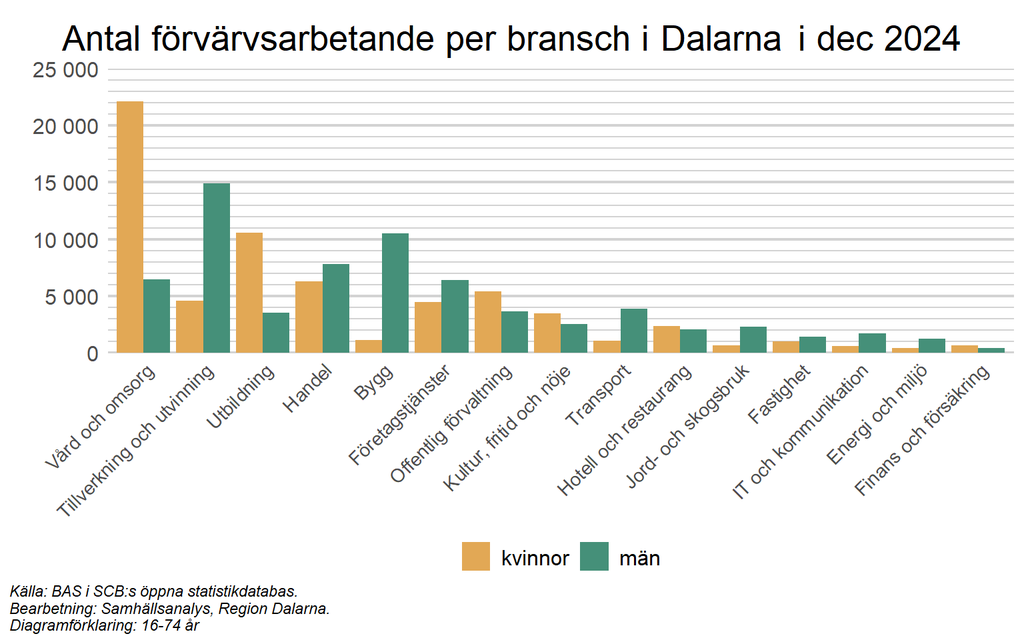

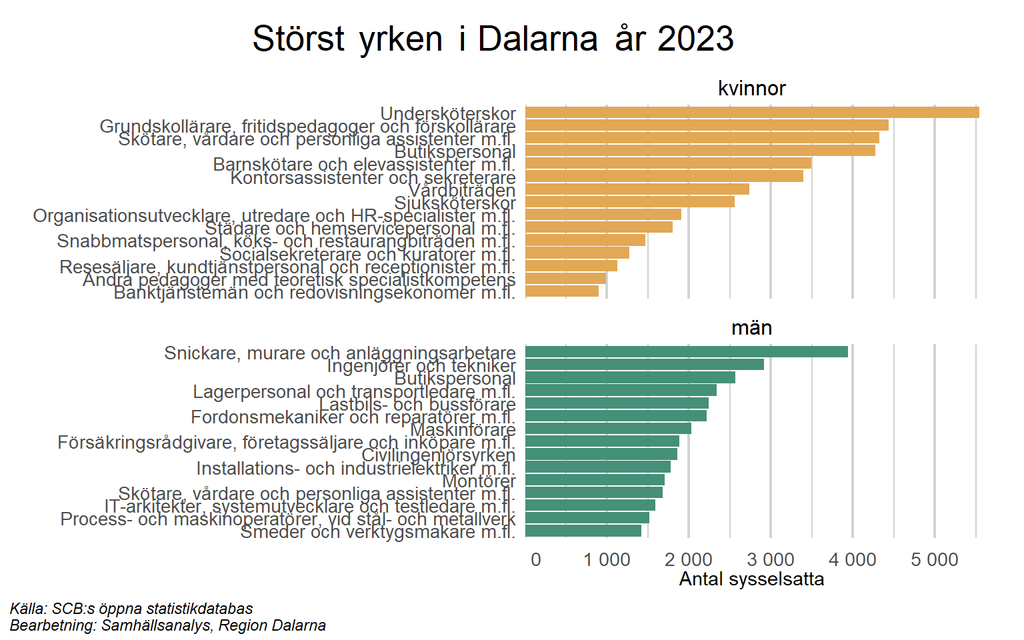

# 2 Ekonomi, inkomster och sysselsättning

Ekonomisk jämställdhet är ett av de sex jämställdhetspolitiska delmålen och syftar till att kvinnor och män ska ges samma möjligheter och villkor i fråga om betalt arbete för att säkerställa ekonomisk självständighet livet ut. Målet utgår således ifrån ett livscykelperspektiv och understryker betydelsen av att det avlönade arbetet ska ge ekonomisk trygghet och självständighet även under pensionsåren. En central förutsättning för inkomst och egen försörjning är anknytning till och förutsättningar på arbetsmarknaden, därför redogörs här även för sysselsättningsgrad och arbetslöshet samt etableringstid för invandrade.

Ekonomisk jämställdhet analyseras genom flera olika inkomstflöden och variabler. Inkomst av arbete utgör merparten av en individs försörjning, men både lönenivå och huruvida personen arbetar hel- eller deltid påverkar inkomsten och sedemera pensionen. Därtill finns kapitalinkomster och offentliga bidrag så som exempelvis sjukpenning, föräldrapenning och bostadsbidrag, som gör att ett centralt mått för att fånga en individs ekonomiska standard är disponibel inkomst. Disponibel inkomst innebär den summa pengar som ett hushåll eller en person har efter att alla ekonomiska inkomster är sammanräknade (lön, avkastning, bidrag etc.) och skatter och avgifter är betalda.

Det finns många faktorer som bidrar till ojämställdhet på arbetsmarknaden och för livsinkomsten, men familjebildningen är den faktor som i högst grad bidrar till ojämställda livsinkomster. Gapet i disponibel inkomst mellan kvinnor och män är som störst för sammanboende, 35 procent, när det yngsta barnet är 0–3 år [(Regeringen (2022))](https://www.regeringen.se/contentassets/46945970585240a4a5bfd9a0f75ecf3d/ekonomisk-jamstalldhet.pdf)[^6].

Löneskillnaderna mellan könen börjar i relativt ung ålder och redan vid 29 års ålder har män i genomsnitt 20 procent högre lön än kvinnor. En del av skillnaden kan förklaras av skillnader i utbildning, då fler kvinnor väljer att studera och då kommer ut senare i arbetslivet. Trots en högre utbildning kvarstår dock gapet i lön mellan könen [(Jämställdhetsmyndigheten (2025))](https://jamstalldhetsmyndigheten.se/media/llefhgq1/kunskapssammanst%C3%A4llning-ungas-ekonomi-2025-1.pdf)[^7].

Vid pensionering finns det numera många som fortsätter att arbeta hel- eller deltid, så kallade jobbonärer, dessa har relativt god ekonomi. De som har det sämst ställt efter pensionering är kvinnor som inte fortsätter att arbeta.

## 2.1 Inkomst

En egen inkomst är en av förutsättningarna för ett ekonomiskt självständigt liv. Livsinkomsten påverkar även vilken pension personen kommer att få vid pensionering.

En jämförelse mellan löner för kvinnor och män i arbetsför ålder (20-64 år) i Dalarna visar på stora skillnader och dessa har hållit i sig över tid. Medianinkomsten för en man i Dalarna var 2023 cirka 409 tusen kronor före skatt, medan en kvinna hade en medianinkomst på ungefär 341 tusen kronor. I den andra figuren nedan syns även en positiv utveckling i form av att den relativa skillnaden i inkomst mellan könen har minskat sedan millennieskiftet. Diagrammet visar att kvinnors medianinkomst har ökat med 117 procent sedan slutet på 1990-talet, medan mäns har ökat med ungefär 98 procent. Det är dock viktigt att notera att figurerna nedan endast redovisar kvinnors och mäns skilda ekonomiska förutsättningar, medan det kan finnas flera förklaringar till skillnaden. En faktor är att kvinnor i högre grad arbetar deltid, och därför kan ha en lägre årsinkomst. Som vi också sett i ett flertal tidigare figurer finns det stora skillnader mellan könen kopplat till bland annat yrke och utbildning, vilket ytterligare kan förklara en del av skillnaden.

På nationell nivå har SCB jämfört den standardvägda lönen, dvs. lönen när hänsyn tas till bland annat ålder och utbildningsnivå, för att synliggöra om det kan finnas en diskrimineringsaspekt i lönenivån. Slutsatsen blev att kvinnors standardvägda lön är ungefär 95 procent av männens standardvägda lön, det vill säga det finns en oförklarad löneskillnad mellan kvinnor och män [(SCB)](https://www.statistikdatabasen.scb.se/pxweb/sv/ssd/START__AM__AM0110__AM0110B/LonStandVagdYrkA/).

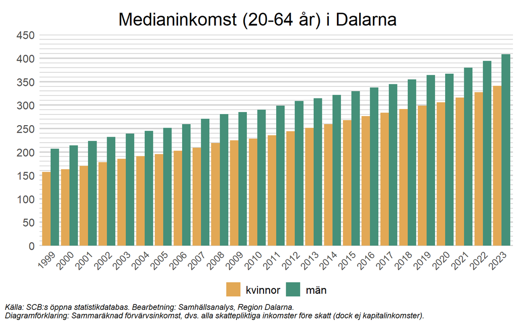

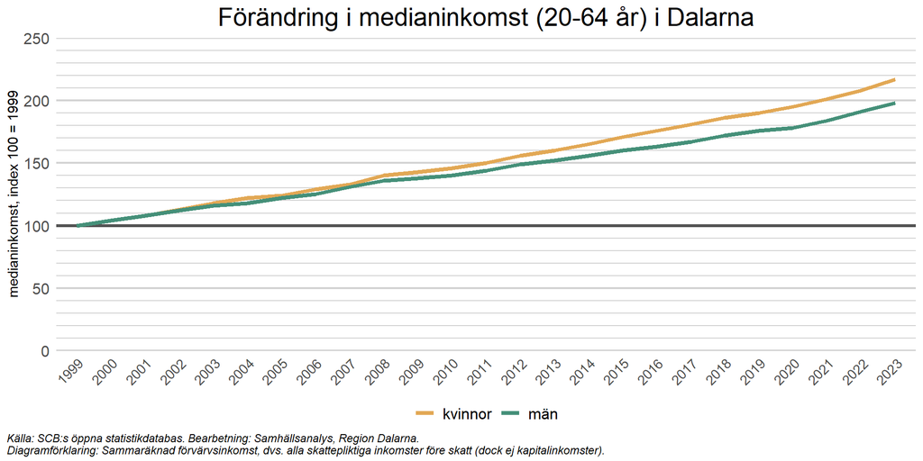

I samtliga av Dalarnas kommuner har männen högre medianinkomst än kvinnorna. Skillnaderna mellan kommunerna är relativt små. Kvinnor har högst medianinkomst i Falun och män i Smedjebacken. Lägst medianinkomst har kvinnor i Vansbro, medan män har lägst medianinkomst i Orsa.

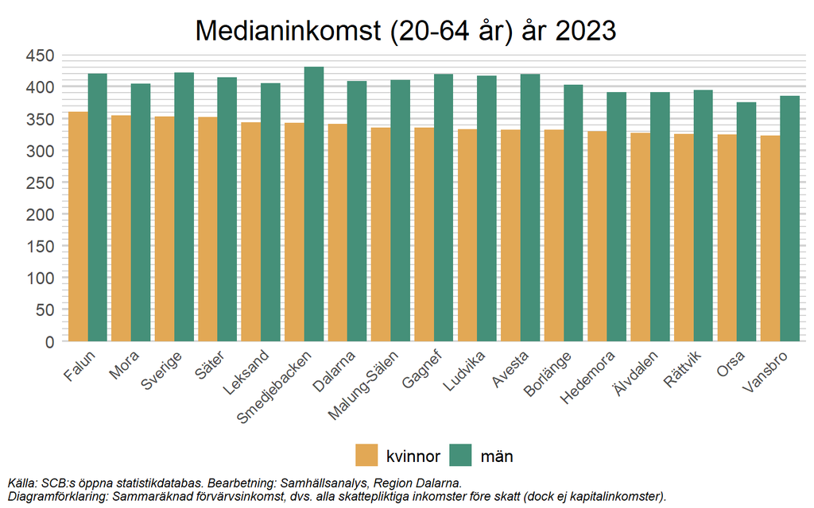

Personer 65 år och äldre har en lägre medianinkomsten än personer i arbetsför ålder (20-64 år). I Dalarna var medianinkomsten år 2023 för män 65 år och äldre 278 tusen kronor före skatt, medan en kvinna i samma åldersgrupp hade en medianinkomst på 218 tusen kronor. Att inkomsterna är lägre för personer 65 år och äldre är rimligt eftersom många i den åldern har gått i pension och då har lägre inkomster än de hade när de förvärvsarbetade.

I den andra figuren nedan syns dock att den relativa skillnaden i inkomst mellan könen har minskat mer sedan slutet på 1990-talet för personer äldre än 65 år, jämfört med de i arbetsför ålder (20-64 år). Diagrammet visar att kvinnors medianinkomst har ökat med 167 procent medan mäns har ökat med ungefär 93 procent.

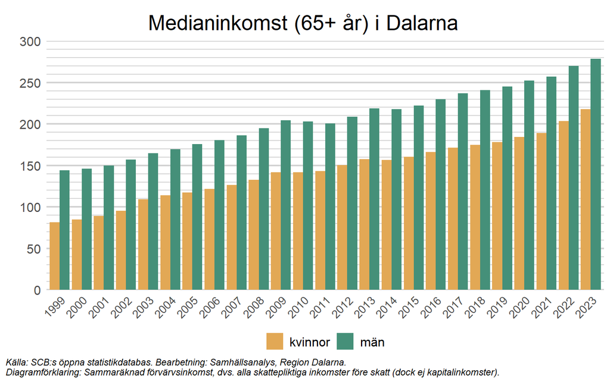

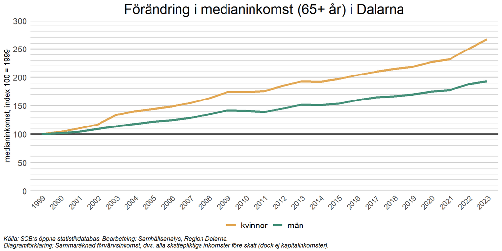

Utöver inkomster är det även relevant att jämföra den disponibla inkomsten, dvs. summan av alla inkomster och transfereringar (exempelvis bostadsbidrag och barnbidrag) efter avdragen slutlig skatt. I figuren nedan är det tydligt att den disponibla inkomsten varierar mellan olika grupper. En generell trend för alla grupper är att den disponibla inkomsten, utan att justera för inflation, har ökat mellan 2011-2023.

Det är tydligt att sammanboende, med eller utan barn, har en högre disponibel inkomst än ensamstående. Sammanboende med barn har också en högre disponibel inkomst än sammanboende utan barn. På andra sidan av skalan återfinns gruppen ensamstående kvinnor utan barn som har lägst disponibel inkomst. Diagrammet visar också på att det finns tydliga skillnader mellan könen. Bland ensamstående har män, med eller utan barn, högre disponibel inkomst än kvinnor i motsvarande grupp.

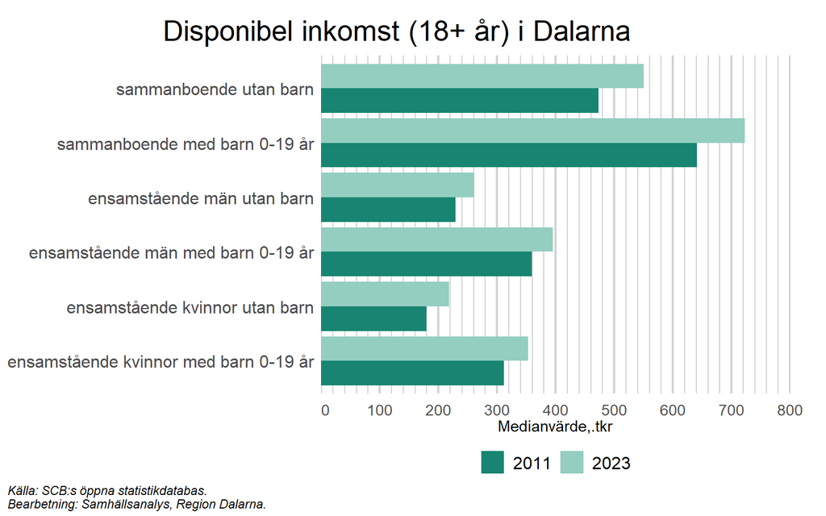

## 2.2 Sysselsättning och arbetslöshet

Sysselsättningsgraden, det vill säga i vilken utsträckning människor i arbetsför ålder (20-64 år) arbetar, skiljer sig inte märkbart åt mellan könen bland inrikes födda som ses i det vänstra diagrammet nedan. Sverige ligger långt fram i en internationell jämförelse när det gäller att ge kvinnor och män likvärdiga möjligheter att yrkesarbeta, och det återspeglas i sysselsättningsgraden som för båda könen är ungefär lika hög, cirka 84 procent. Variationen i sysselsättningsgrad mellan länen är därför också relativt liten.

Däremot skiljer sig sysselsättningsgraden åt mellan inrikes och utrikes födda. För utrikes födda (det högra diagrammet nedan) är sysselsättningsgraden lägre än sysselsättningsgraden för inrikes födda i samtliga svenska län. Det finns även skillnader mellan kvinnor och män.

Utrikes födda män har en högre sysselsättningsgrad än utrikes födda kvinnor i samtliga län förutom Norrbotten. I Dalarna var sysselsättningsgraden bland utrikes födda män ungefär 71 procent, vilket är cirka 7 procentenheter mer än för utrikes födda kvinnor i Dalarna.

Något att ta hänsyn till när man analyserar sysselsättningsgrad och arbetslöshet bland utrikes födda är hur lång tid individen har varit i Sverige. Vistelsetid i Sverige har ett starkt samband med sysselsättningsgrad och arbetslöshet och därmed kommer andelen nyligen invandrade i gruppen utrikes födda att påverka nivån på dessa variabler, se rubrik 2.3.

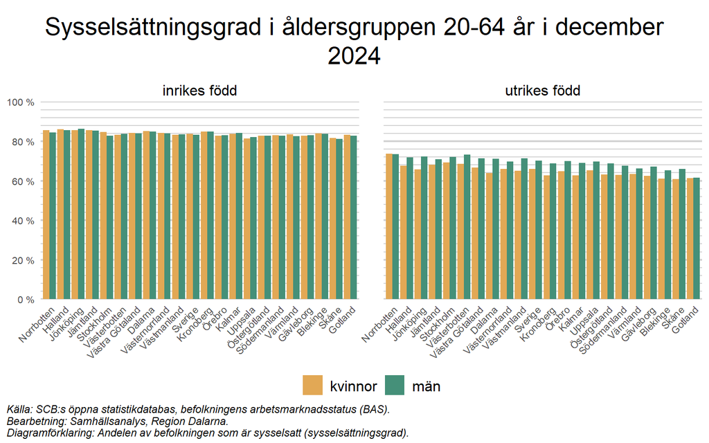

Sysselsättningsgraden i respektive kommun i Dalarna visar ett liknande mönster som länen på nationell nivå. Gruppen inrikes födda har en högre sysselsättningsgrad i samtliga kommuner i Dalarna jämfört med utrikes födda. Även här är sysselsättningsgraden för inrikes födda kvinnor och män ungefär lika hög. För utrikes födda är det däremot stora skillnader mellan kvinnor och män, också mellan olika kommuner. I linje med den nationella bilden är sysselsättningsgraden högre för gruppen utrikes födda män i jämförelse med utrikes födda kvinnor i de allra flesta kommuner (undantagen är Orsa och Smedjebacken). Sysselsättningsgraden för utrikes födda män skiljer sig dock åt mellan kommuner där den högsta sysselsättningsgraden finns i Mora (knappt 77 procent) och den lägsta i Smedjebacken (drygt 64 procent).

Falun har den högsta sysselsättningsgraden för gruppen utrikes födda kvinnor i Dalarna, runt 72 procent, och ligger klart över genomsnittet för länet (knappt 64 procent). Samtidigt är sysselsättningsgraden i Avesta kommun bland utrikes födda kvinnor bara ungefär 58 procent.

Värt att notera är att en del av skillnaden i utrikes föddas sysselsättningsgrad mellan kommunerna sannolikt kan förklaras av skillnader i antalet personer som invandrade under åren runt 2015 då invandringen till Sverige var mycket stor. Exempelvis var Avesta, Ludvika och Hedemora de tre kommuner som hade högst invandring i förhållande till folkmängd under 2015, 2016 och 2017. Detta verkar i första hand gälla för utrikes födda kvinnor, då både Hedemora och Ludvika har relativt hög sysselsättningsgrad för utrikes födda män, medan den är klart lägre för utrikes födda kvinnor. I Ludvika är skillnaden mellan könen i sysselsättningsgrad ungefär 15 procentenheter, vilket är den största skillnaden i länet.

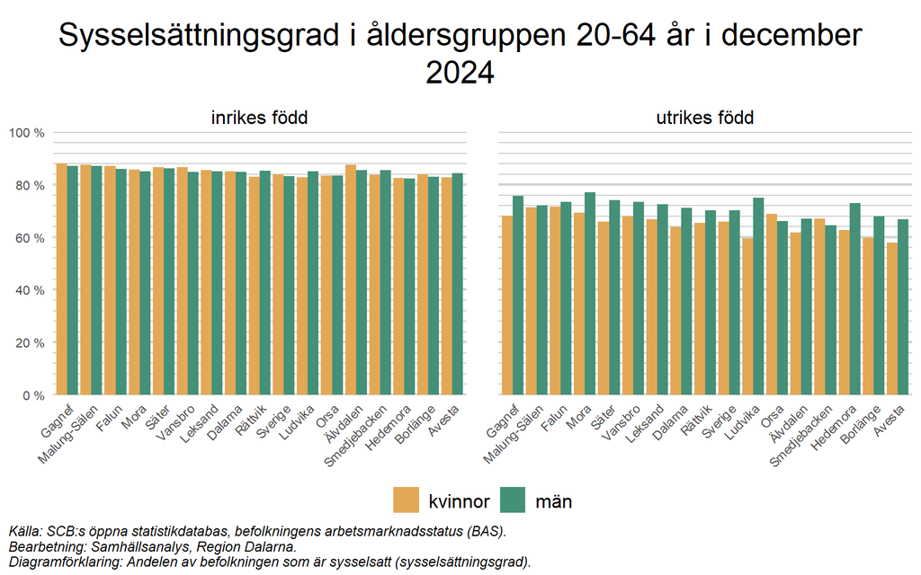

Bilden av arbetsmarknaden kompletteras genom att titta på arbetslösheten som visar hur många av de aktivt arbetssökande som inte har ett arbete. En jämförelse av arbetslösheten bland utrikes respektive inrikes födda åskådliggör ett antal viktiga skillnader.

Arbetslösheten är generellt högre för utrikes födda än för inrikes födda. Arbetslösheten för inrikes födda i Dalarna ligger något lägre än rikets, cirka 2 procent bland kvinnor och drygt 3 procent bland män (se diagrammet nedan).

Arbetslösheten bland utrikes födda är däremot betydligt högre i samtliga av Sveriges län. I Dalarna är skillnaden i arbetslöshet mellan utrikes och inrikes födda cirka 12 procentenheter för kvinnor och cirka 9 procentenheter för män. Vidare är arbetslösheten bland gruppen utrikes födda kvinnor klart högre än i gruppen utrikes födda män i samtliga av Sveriges län.

I figuren nedan framgår också att det finns avsevärda skillnader mellan länen. Norrbotten har den lägsta arbetslösheten för utrikes födda med ungefär 7 procent totalt (både kvinnor och män), medan arbetslösheten är cirka 19 procent i Gävleborg. Dalarnas län ligger något över riksgenomsnittet, men uppvisar inte extrema arbetslöshetssiffror åt något håll.

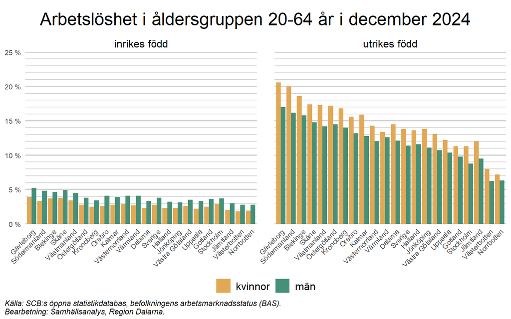

Precis som var fallet med sysselsättningsgrad tidigare, så uppvisar Dalarnas kommuner ett liknande mönster som på nationell nivå. Bland inrikes födda är arbetslösheten låg och något fler män än kvinnor är arbetslösa. Högst arbetslöshet bland inrikes födda (totalt) i Dalarna finns i Hedemora, men skillnaden gentemot genomsnittet i länet är relativt liten (ungefär 1 procentenhet). Lägst arbetslöshet återfinns i Malung-Sälen.

Det är återigen värt att notera att de skillnader i arbetslöshet som diskuterades i stycket om sysselsättningsgrad ovan, sannolikt delvis kan förklaras av skillnader i antalet personer och när i tid som de invandrat till olika kommuner.

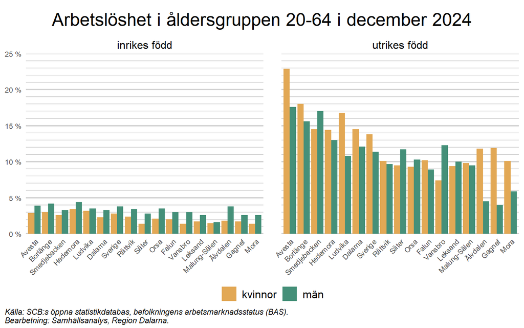

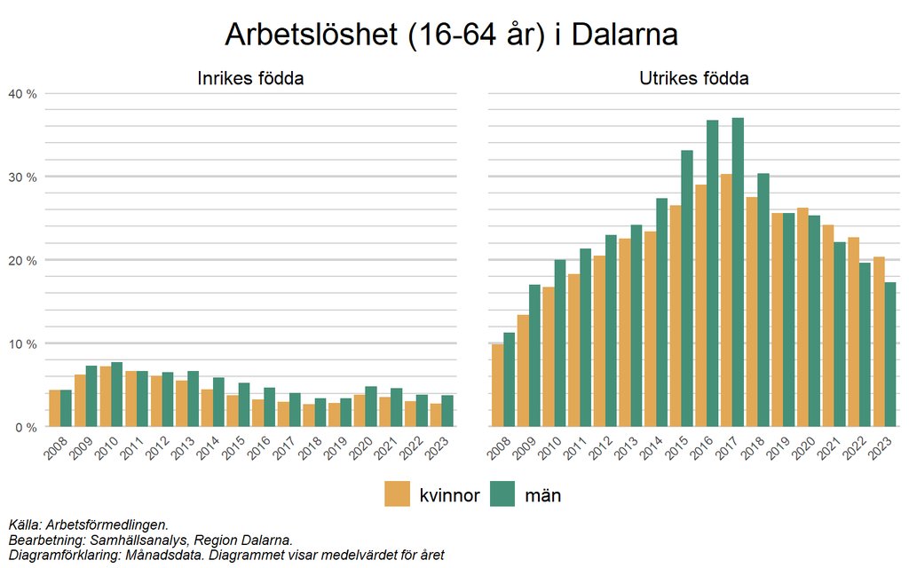

Hur långt ifrån arbetsmarknaden som en individ befinner sig beror delvis på hur länge personen har varit utan anställning. En person som har varit arbetslös länge har ofta svårare att ta sig tillbaka in på arbetsmarknaden. Som långtidsarbetslös räknas den som har varit öppet arbetslös eller i program med aktivitetsstöd i minst sex månader. År 2011 noterades 3 procent av länets kvinnor i åldern 25-64 år som långtidsarbetslösa, medan motsvarande siffra för männen var 2,9 procent. Under 2010-talet gick långtidsarbetslösheten såväl upp som ned, innan den nådde sin topp i samband med pandemin 2020-2021. På senare år har långtidsarbetslösheten minskat tydligt och var år 2024 i Dalarna något högre för män, men något lägre för kvinnor jämfört med 2011. Långtidsarbetslösheten i Sverige är högre än i Dalarna för båda könen. En generell orsak till långtidsarbetslöshet är strukturarbetslöshet som innebär att de arbetssökande saknar rätt kompetens för de arbeten som finns tillgängliga.

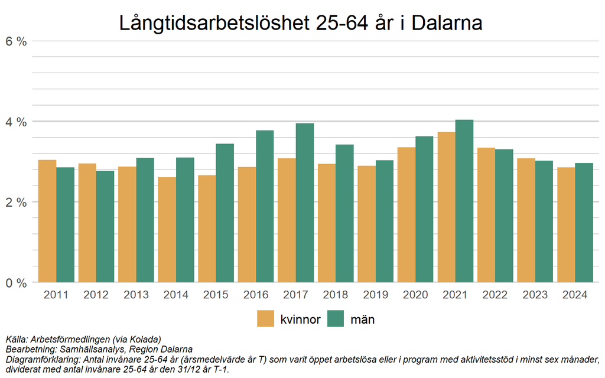

## 2.3 Arbetsmarknadsetablering för invandrade

Som diskuterats tidigare är sysselsättningsgraden lägre bland utrikes födda generellt, och för invandrade kvinnor tar det betydligt längre tid än för invandrade män att etablera sig på arbetsmarknaden. För utrikesfödda kvinnor som befunnit sig i Sverige i upp till 2 år (0-1 år i grafen nedan) är det bara ungefär 31 procent i arbetsför ålder (20-65 år) som arbetar. För motsvarande grupp av män är ungefär 62 procent i arbete inom 2 år. Över tid tenderar ändå etableringsgraden att öka avsevärt och efter mer än tio år i Sverige är det över 70 procent av invandrade såväl män som kvinnor som arbetar.

Skillnaden mellan utrikes födda kvinnor och utrikes födda män kan bland annat förklaras med att kvinnor som invandrat från ett utomeuropeiskt land i majoriteten av fallen har gjort det som anhörig, antingen till en person med svenskt medborgarskap eller till en person med permanent uppehållstillstånd. Att vara anhörig till arbetskraftsinvandrare är även vanligt förekommande. Givet dessa skäl för invandring är det vanligt att kvinnor invandrar med små barn eller har ett högt barnafödande de första åren i landet. Det har visat sig att kvinnorna sedan tar ett betydligt större omsorgsansvar för barn än barnens fäder, vilket bidrar till att deras inträde på arbetsmarknaden sker betydligt senare än för män i motsvarande situation. Exempelvis är användningen av föräldrapenning mycket ojämställd bland nyligen invandrade föräldrar. Se exempelvis [Expertgruppen för studier i offentlig ekonomi (2021)](https://eso.expertgrupp.se/wp-content/uploads/2020/03/ESO-2021_7_forsorjning-med-fordrojning_webb.pdf)[^8] och [Jämställdhetsmyndigheten (2022)](https://jamstalldhetsmyndigheten.se/media/s5wdbimq/rapport-sta-rkta-mo-jligheter-genom-samverkan.pdf)[^9].

Att vara anhöriginvandrare sätter också kvinnan i fråga i en särskild beroendeställning till sin respektive anhörige i jämförelse med om hon invandrat/flytt på egna premisser. Detta i kombination med ofta låg utbildning och brist på arbetslivserfarenhet från hemlandet blir också hinder för att delta i integrationsinsatser, utbildning och arbetssökande. Se exempelvis [Expertgruppen för studier i offentlig ekonomi (2021)](https://eso.expertgrupp.se/wp-content/uploads/2020/03/ESO-2021_7_forsorjning-med-fordrojning_webb.pdf)[^10] och [Regeringen (2023)](https://www.regeringen.se/contentassets/aaae962745b74fa4abc01f7926bb5adc/sou-2023_24_pdf-a_webb.pdf)[^11].

Regeringen har under år 2023 satt fokus på insatser som ska få utrikes födda kvinnor i arbete snabbare. Bland annat har länsstyrelserna ett regionalt uppdrag med detta mål.

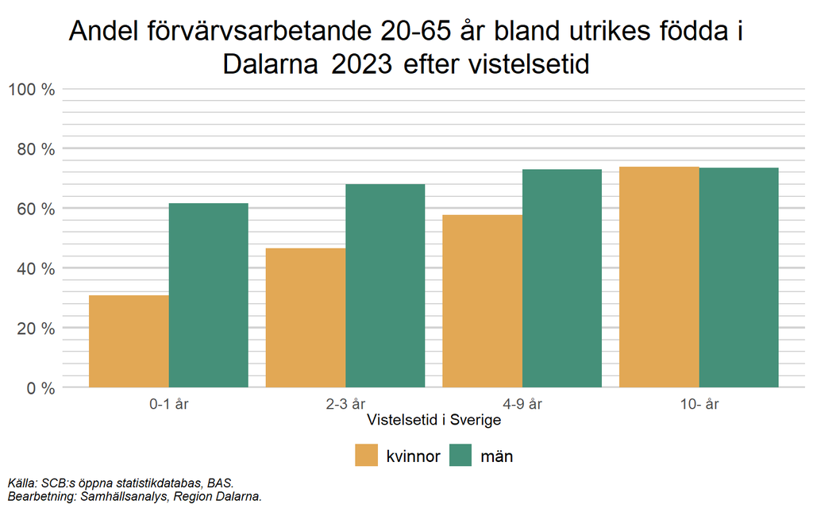

Hur snabbt en nyligen invandrad person etableras på arbetsmarknaden är också nära kopplat till vilken utbildningsnivå personen har. För dem med högst utbildning har det visat sig att processen tenderar att gå relativt snabbt och cirka 48 procent av kvinnorna och 74 procent av männen arbetar innan de varit i Sverige i 2 år (0-1 år i figuren nedan). Sedan ökar etableringsgraden över tid och efter 10 år och längre är fler än 80 procent av kvinnorna mellan 20 och 65 år sysselsatta, vilket är i linje med sysselsättningsgraden för inrikes födda kvinnor i samma åldersgrupp. För dem med exempelvis gymnasial utbildning är situationen delvis annorlunda. I den gruppen arbetar ungefär 28 procent av de utrikesfödda kvinnor, och cirka 58 procent av de utrikesfödda männen, inom 2 år efter att de kommit till Sverige. Över tid ökar andelen etablerade snabbt på arbetsmarknaden, särskilt för gymnasialt utbildade.

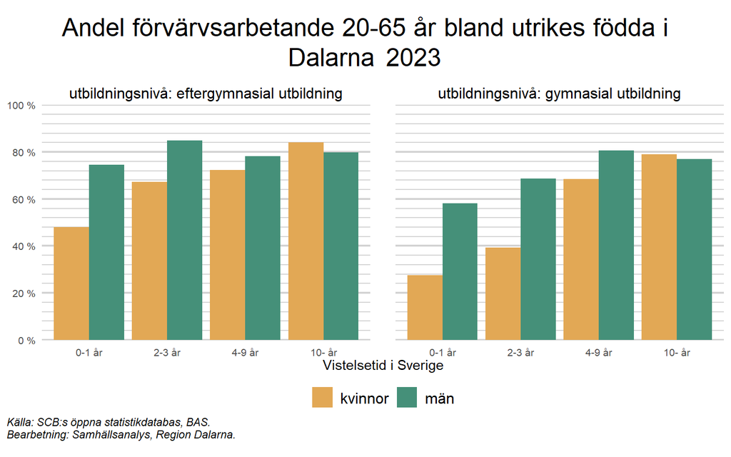

Hur snabbt en nyligen invandrad person etablerar sig på arbetsmarknaden har förändrats avsevärt över tid, vilket åskådliggörs i diagrammet nedan. Från början av 2000-talet fram till mitten av 2010-talet låg etableringstiden relativt stabil, där ungefär 20 procent av de 20-64 åringar som varit i Sverige i upp till 2 år (0-1 år i figuren nedan) förvärvsarbetade och ungefär 50-60 procent av de 20-64 åringar som varit i Sverige mellan 4 och 10 år (4-9 år i figuren nedan) förvärvsarbetade. Efter den stora flyktinginvandringen i mitten av 2010-talet verkar dock någonting ha hänt och framförallt personer med kort vistelsetid (upp till 2 år) kommer i arbete betydligt snabbare. Mellan 2015 och 2023 ökade andelen förvärvsarbetande av de 20-64 åringar som varit i Sverige i upp till 2 år (0-1 år i figuren nedan) från ungefär 14 procent till cirka 46 procent, en remarkabel förbättring. Under samma tidsperiod har även arbetslösheten för gruppen utrikes födda minskat betydligt, vilket illustrerats i ett tidigare diagram. Värt att notera är att det i diagrammet nedan är andelen förvärvsarbetande i åldersgruppen 20-64 år som redovisas mellan 1997 och 2021, medan det är andelen förvärvsarbetande i åldergruppen 20-65 år som redovisas åren därefter.

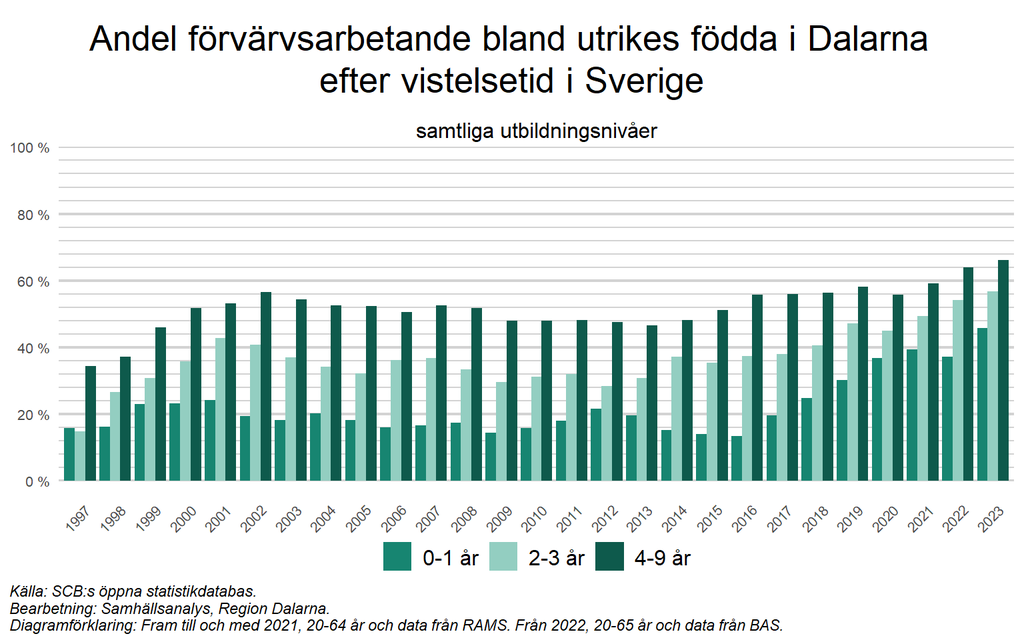

## 2.4 Skulder hos Kronofogden

Ytterligare en aspekt av ekonomisk status är att ha skulder hos Kronofogden, vilket både är bekymmer för individen och orsakar stora kostnader för samhället. I det första diagrammet nedan redovisas antalet personer i Dalarna som har skulder under indrivning hos Kronofogden. Två trender är tydliga.

Sedan 2010 har antalet med skulder hos Kronofogden minskat från ungefär 10 300 personer till cirka 9 300 i Dalarnas län. Av dessa är ungefär 60 procent män och 40 procent kvinnor, en fördelning som inte har förändrats över tid. Det är således avsevärt fler män än kvinnor i länet som har skulder hos Kronofogden. Värt att notera är dock att antalet har börjat öka på senare år, vilket kan vara en effekt av högre bolåneräntor och ökad inflation, något som bland annat fått till följd att matpriserna stigit avsevärt [(SVT)](https://www.svt.se/nyheter/ekonomi/nara-tre-ar-med-hog-inflation-sa-dyr-blev-maten).

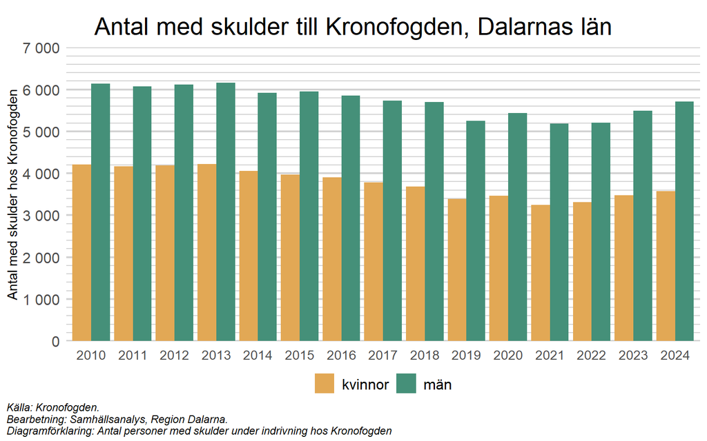

Som andel av befolkningen i Dalarna år 2024 utgör kvinnor med skulder hos Kronofogden 3,1 procent och män 4,9 procent. Medianskulden var för kvinnor ungefär 66 000 kr och för män cirka 82 200 kr [(Kronofogden)](https://kronofogden.se/om-kronofogden/statistik/statistik-om-antal-skuldsatta).

Störst andel skuldsatta finns i åldersintervallet 26-34 år, år 2024 var 7,5 procent av männen och 4,8 procent av kvinnorna i Dalarna i denna åldersgrupp skuldsatta.

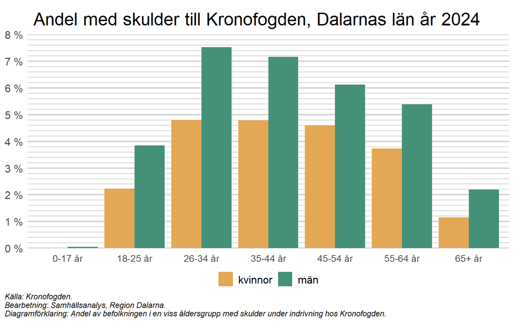

I diagrammet nedan redovisas antalet långsiktigt skuldsatta i Dalarna, vilket betyder indivder som under minst 20 års tid har haft skulder till Kronofogden. Även här finns det betydligt fler män än kvinnor till antalet. Åren 2013 - 2016 var en period med ett större antal skuldsatta i båda grupperna, men därefter har antalet minskat bland både kvinnor och män. Mätt över tidsperioden 2010 - 2024 har antalet män minskat med 13 procent medan antalet kvinnor istället har ökat med 17 procent.

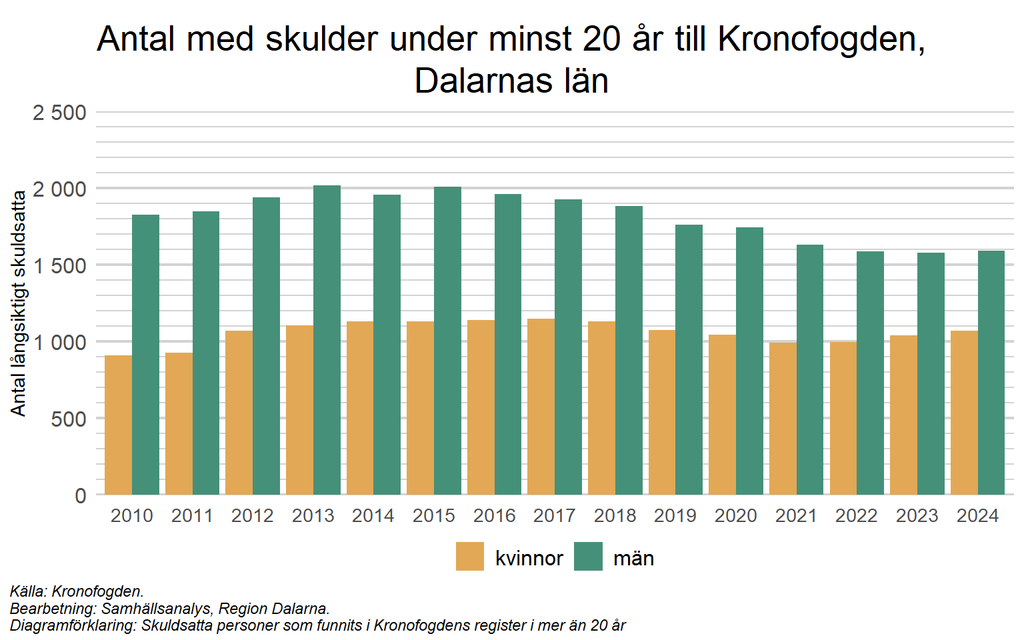

# 3 Obetalt hem- och omsorgsarbete

En jämn ansvarsfördelning för obetalt hem- och omsorgsarbete är det fjärde jämställdhetspolitiska delmålet. Jämställdhetsmyndigheten har sammanfattat nuläget för delmålet nationellt. De skriver på sin [hemsida](https://jamstalldhetsmyndigheten.se/jamstalldhet-i-sverige/delmal-4-jamn-fordelning-av-det-obetalda-hem-och-omsorgsarbetet/):

> Kvinnor tar fortfarande i hög grad ansvar för det obetalda hem- och omsorgsarbetet. De tar ut mer av föräldraförsäkringen och lägger mer tid på att ta hand om barn. Kvinnor och män ger omsorg, men på olika sätt. Kvinnors omsorgsarbete tycks dock påverka dem mer negativt än män. I hemmet är det främst kvinnor som städar, lagar mat och tvättar medan män klipper gräset, tar hand om bilen och sköter ekonomin.

Ett större ansvar för det obetalda arbetet minskar ofta utrymmet för inkomstbringande arbete och påverkar på så sätt individernas livsinkomster. Det kan också skapa ett beroende till en partner med en högre inkomst.

## 3.1 Föräldrapenning

Antalet mottagare av föräldrapenning ökade från ungefär 13 000 i slutet av 1990-talet till över 22 000 år 2018. Givet att den absoluta majoriteten av dessa barn har två vårdnadshavare är det värt att notera att det varje år är cirka 10 procent av fäderna som inte tar ut några föräldrapenningdagar alls.

En minskning i antalet föräldrapenningdagar syntes under pandemiåren och åren därefter, vilket sannolikt beror på att uttaget av tillfällig föräldrapenning (vab) då ökade kraftigt (se avsnitt 3.2 nedan). Antalet uttagna dagar har ökat för såväl kvinnor som män, men den relativa skillnaden i uttag mellan könen har minskat.

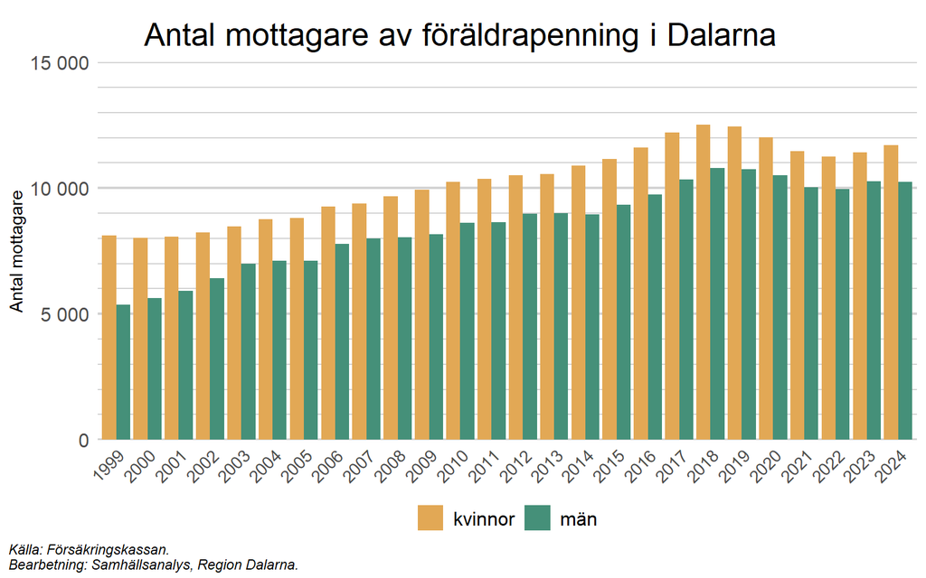

Fördelningen av dagar mellan vårdnadshavarna har jämnats ut något sedan slutet av 1990-talet då runt 85-90 procent av föräldrapenningdagarna togs ut av mammorna. Sedan dess har först en (1995), sedan två (2002) och även tre månader (2016) reserverats åt respektive vårdnadshavare (också kallade “pappamånader”). Detta har bidragit till ett jämnare uttag men utvecklingen får ändå sägas gå relativt trögt, då kvinnors andel endast har minskat till runt 69 procent 2024. Svenska vårdnadshavare är således långt ifrån att ge sina barn en jämställd tillgång till sina föräldrar. Skillnaden i uttag påverkar också den disponibla inkomsten, som beskrivits under rubriken Ekonomisk jämställdhet. Skillnaden är som störst mellan sammanboende kvinnor och män när det yngsta barnet är 0–3 år [(Regeringen, 2022)](https://www.regeringen.se/contentassets/46945970585240a4a5bfd9a0f75ecf3d/ekonomisk-jamstalldhet.pdf)[^12].

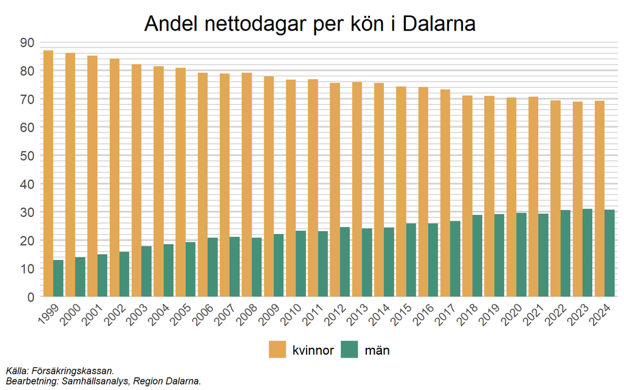

Hur vårdnadshavare fördelar föräldrapenningen mellan sig är relativt olika i Dalarnas kommuner. I Leksand och Orsa är uttaget mest jämställt relativt sett, där drygt 33 procent av föräldrapenningdagarna togs ut av männen. Minst jämställd är fördelningen i Vansbro, där motsvarande uttag är cirka 28 procent.

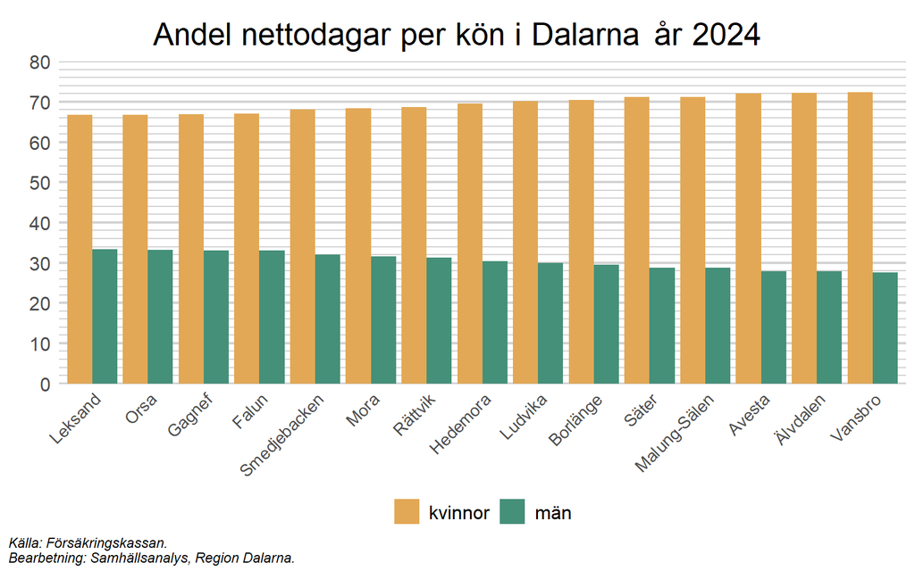

Antalet uttagna nettodagar av föräldrapenning är inte jämnt fördelade över året. Mest benägna är såväl kvinnor som män att ta ut dagar i juli och augusti, sannolikt för att ha möjlighet att vara hemma med barnen under deras skollov på sommaren. Även januari är en populär månad, troligtvis fokuserat i början av månaden när barnen är lediga från förskola och skola.

Ett påstående som ibland förs fram är att män är mer benägna att ta ut dagar under exempelvis älgjakten (september och oktober primärt) eller under större idrottsevenemang, men någon sådan tendens syns inte i statistiken som ses i diagrammet nedan. Män tar i första hand ut sina dagar under januari, juli och augusti, medan det är relativt jämnt fördelat mellan övriga månader. Visserligen sticker september ut som en månad med relativt många uttagna dagar, men det gäller för såväl kvinnor som män och bör således inte vara kopplat till eventuell älgjakt under månaden.

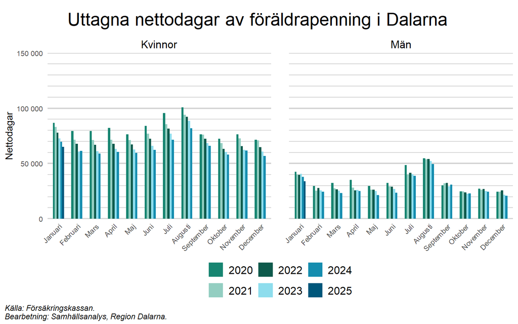

## 3.2 Tillfällig föräldrapenning

Tillfällig föräldrapenning ges för vård av sjukt barn och är det som i folkmun kallas vab. Sett över tidsperioden minskade antalet uttagna nettodagar något mellan 2006 och 2009, för att därefter öka stadigt fram till 2022. På senare år har uttaget av tillfällig föräldrapenning/vab för såväl kvinnor som män minskat, men ligger fortfarande på högre nivåer än innan pandemin. Även för vård av sjukt barn tar kvinnor ut betydligt fler dagar än män, fördelningen ligger precis utanför spannet för vad som antas som statistisk jämställdhet, där kvinnor tar ut cirka 62 procent av dagarna.

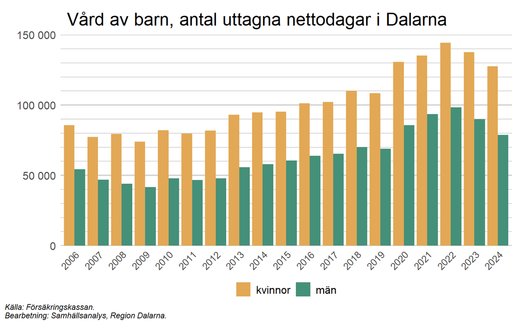

Till skillnad från trenden för föräldrapenning har fördelningen av vab-dagar hållt sig jämnare de senaste decennierna (under pandemin verkar män ha ökat sitt uttag något jämfört med kvinnor).

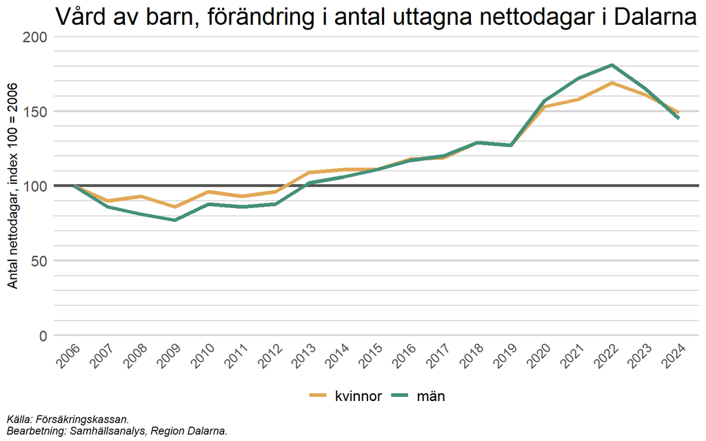